# WIFI Based Traffic Counting

Recently we were asked us to prove whether or not we could quickly, efficiently and discreetly help a city identify traffic patterns in and out of the main drag.

And do it cheaply.

Using our knowledge of wifi based IP protocols and our mad hacking skills we took one of these (a Raspberry Pi):

[figure not shown]

And turned it into a cellphone/wifi detector capable of logging hundreds of cellphones (as long as their wifi was on) per second.

## Conclusion

Yes, for < $200 you can kick off a 2 node Rbpi based network of wifi sniffers capable of logging wifi traffic in and out of the city.

It works really well, is robost and easy to monitor traffic, traffic speeds, and directions.

# The experiment

## Basic stats

- Unique Devices: 869
- Length of Data Collection (hours): 24.3817
- Median Number of Detections per Device: 2
- Active Time (minutes) per Device (50th, 75th and 95th quantiles): 0, 4.9333, 1094.4
- Unique Brand Identifiers: 23
- Median number of Devices per Brand Identifier: 10

## Unique Counts per Device Type (Stationary, Pedestrian, Vehicle)

| type | uniques |
| --- | --- |
| car | 725 |
| pedestrian | 122 |
| stationary | 22 |

## Unique Counts per Brand Identifier (Top Counts shown only)

|  | Ident | detections | uniques |
| --- | --- | --- | --- |
| 101 | Apple | 3725 | 275 |
| 132 | SamsungE | 1568 | 120 |
| 119 | LgElectr | 530 | 67 |
| 122 | Motorola | 672 | 64 |
| 139 | Zte | 186 | 26 |
| 114 | Htc | 213 | 23 |
| 103 | ArrisGro | 7394 | 17 |
| 123 | MurataMa | 160 | 17 |
| 129 | Private | 28 | 14 |
| 121 | Microsof | 65 | 13 |
| 116 | IntelCor | 3419 | 11 |
| 126 | Nokia | 138 | 10 |
| 110 | Drivecam | 11 | 7 |
| 105 | AsustekC | 137 | 6 |
| 113 | HonHaiPr | 8324 | 6 |
| 136 | TctMobil | 11 | 6 |
| 115 | HuaweiTe | 6 | 5 |

## Identifying Stationary, Pedestrians and Cars

Can we detect whether a device is stationary (and local to the detector?), or Wether it might be a pedestrian walking by… or a vechicle zooming by?

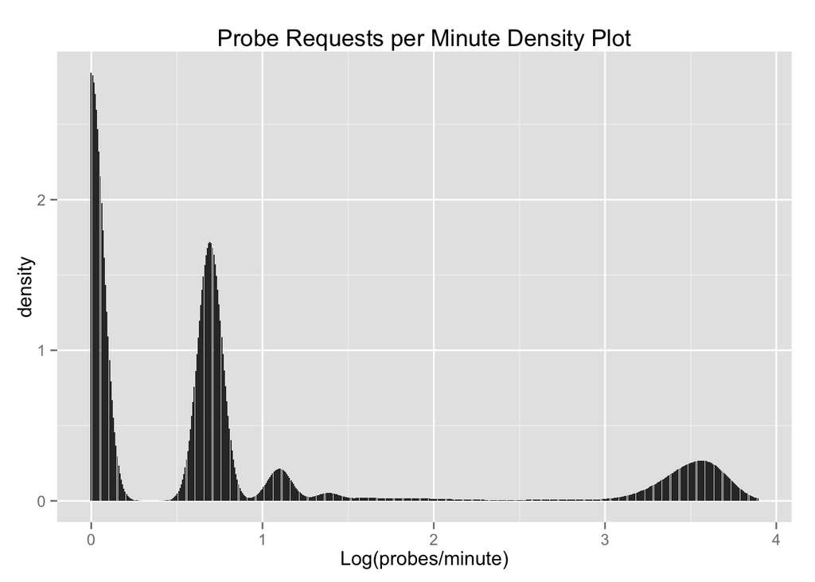

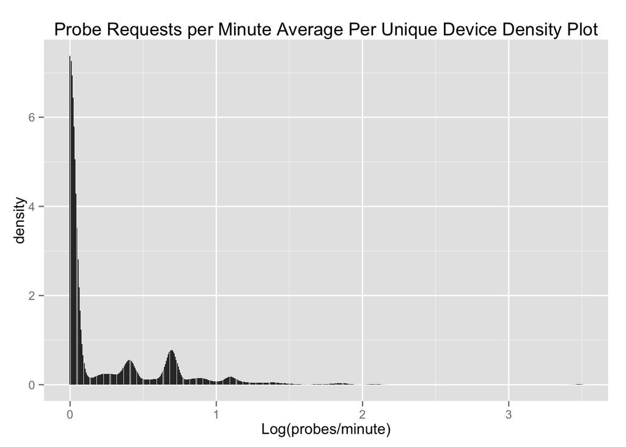

Yes, traffic is likely to have between 0 and 1.6 (exp(.5)) detections as they drive by. While it’s not easy to eyeball, a rule of thumb might be to classify foot traffic as between 1.6 and 3 per minute (exp(.5) to exp(1)). And anything greater than 3 as stationary devices.

More work should be done to more fully detect stationary vs. non-stationary traffic, but for now this is a good rule of thumb.

## Uniques per Minute

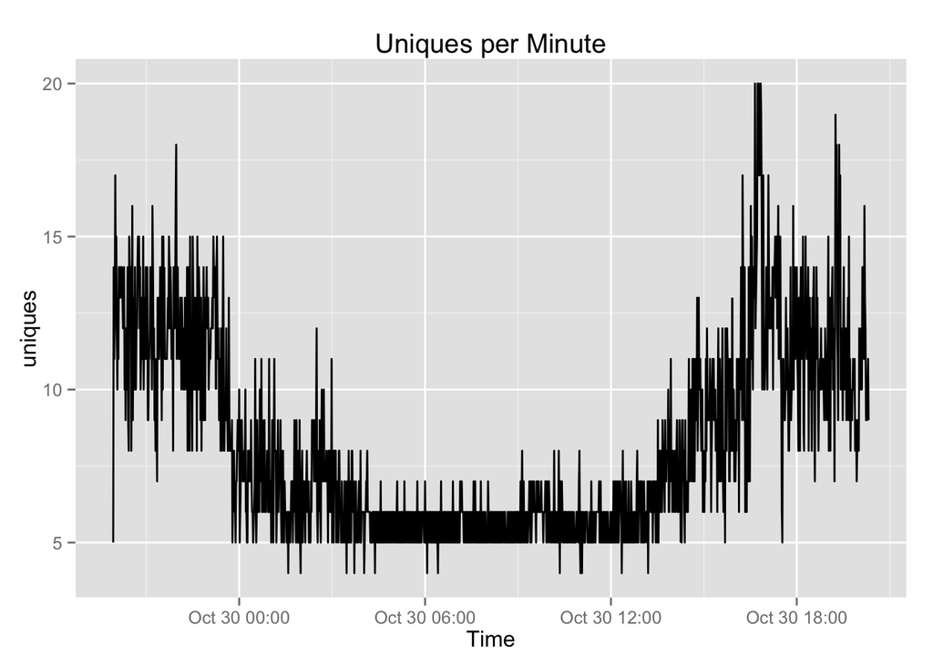

## Uniques per Hour

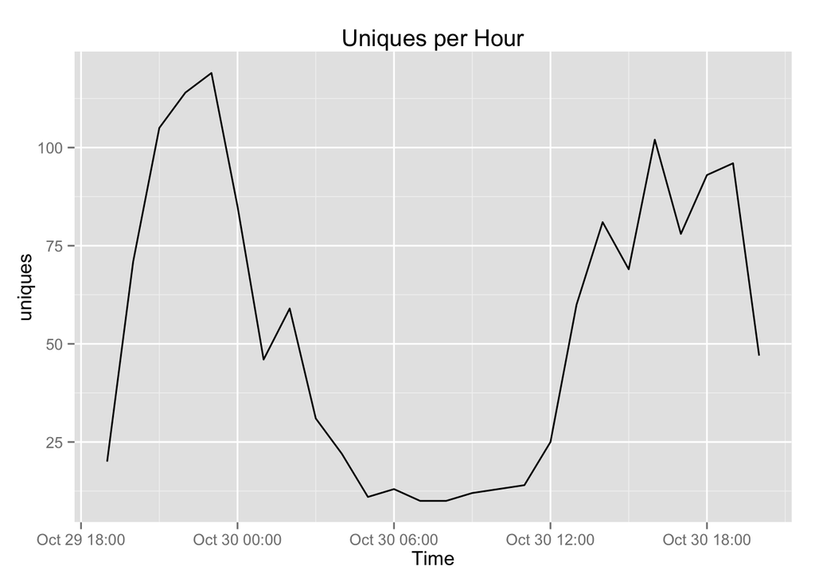

## Uniques by Identifier

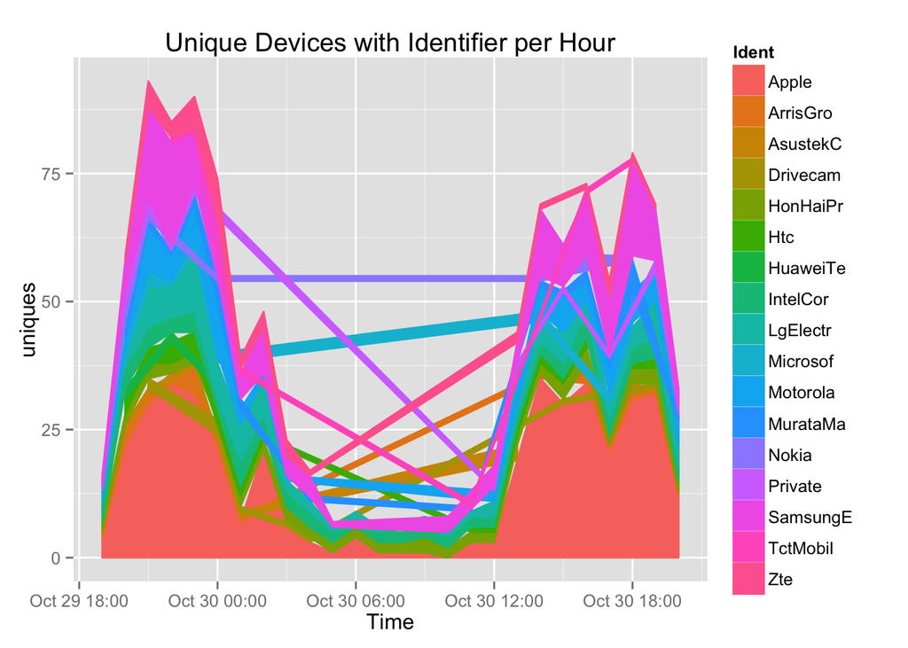

# TBD

- Calibrate with actual counts (where possible)

# Conclusions

It has been shown that an inexpensive device can reliably detect and log unique traffic counts into and out of the city center.